# PLSC 508 Method Tutorial - Reciprocity & Transitivity

Application to Leifeld & Schneider (2012): Information Exchange in Policy Networks

Jody Park

09-15-2026 (Week 4)

# Overview

This tutorial examines **reciprocity** and **transitivity** using the political/strategic information-exchange network from Leifeld & Schneider (2012), “Information exchange in policy networks,” *American Journal of Political Science*, 56(3), 731–744.

I use the [R replication data](https://dataverse.harvard.edu/dataset.xhtml?persistentId=doi:10.7910/DVN/ONDFVJ) from Leifeld & Schneider (2012), including `pol.csv` and the data-import steps in `AJPS.R`, with the [`btergm::chemnet` documentation](https://rdrr.io/cran/btergm/man/chemnet.html) as a supplementary reference to describe mutual partner nominations and the closure of directed two-paths among organizations in the German toxic chemicals policy domain.

The goals of this tutorial are:

- (1) to distinguish dyadic reciprocity from triadic transitivity
- (2) to calculate and interpret these measures
- (3) to explain how network density and tie direction affect their meaning

The analysis follows this week’s readings by Garlaschelli & Loffredo (2004), Holland & Leinhardt (1971), and Tam Cho & Fowler (2010), with the network-dependence framework introduced by Cranmer et al. (2020).

**Table of Contents**

1. Data Walkthrough: Leifeld and Schneider (2012)
2. Reciprocity and Transitivity

# Part 1. Data Walkthrough: Leifeld and Schneider (2012)

## 1.1 Data Description

### Data Sources

The data come from the replication materials for Leifeld & Schneider (2012). The authors study information exchange in the German chemicals-control policy domain using organizational survey data collected in the winter of 1984/1985. Of 47 organizations, 40 responded. The authors retain an influence core of 30 organizations, each identified as influential by at least one other actor.

The paper distinguishes political/strategic information exchange from technical/scientific information exchange. This tutorial focuses on the *political network*, `pol.csv`, to keep the meaning of the relation consistent throughout the analysis.

The local `pol.csv` matches both the Dataverse archive and the `pol` matrix distributed with `btergm::chemnet` (version 1.11.1). The code below reads the CSV file directly; it does not require `btergm`.

*Source note.* The package documentation describes the period as 1983/1984 and reports a 100% response rate for its dataset, whereas the paper reports winter 1984/1985 and 40 responses from 47 actors before selecting the 30-actor core. The documentation also describes political ties as information sending, whereas the paper explicitly defines them as perceived exchange partnerships.

I follow the paper for survey timing and tie interpretation, and distinguish the original survey response rate from the complete matrix used here (Leifeld & Schneider, 2012).

### Libraries

The tutorial uses the following R packages.

```r
# load libraries
library(network) # for network objects and plotting
library(sna) # for network measures and plotting
library(magrittr) # for the pipe operator %>%
library(knitr) # for kable() tables
library(kableExtra) # for kable styling
```

### Key Variables

A **node** represents an organization. A directed **tie**, $i \rightarrow j$, means that organization $i$ identifies organization $j$ as a regular information-exchange partner. The authors emphasize that this network records perceived partnerships; it does not identify who sends information to whom. Thus, reciprocal nominations indicate that both organizations acknowledge the partnership (Leifeld & Schneider, 2012).

Table 1 summarizes the network data and tie definitions.

```r
# key data table
key_vars <- data.frame(
  Item = c("Node", "Directed tie", "pol.csv", "Diagonal"),
  Description = c(
    "Organization in the 30-actor influence core",
    "Row organization names column organization as an exchange partner",
    "Binary matrix: 1 = nominated partner; 0 = no recorded nomination",
    "Self-ties are excluded from the analysis"
  )
)

# plot a descriptive table
t0 <- kable(key_vars, format = "html", caption = "Network Data",
             align = c("l", "l")) %>%
  kable_styling(full_width = TRUE,
                bootstrap_options = c("hover", "condensed", "responsive"))

t0
```

Table 1: Network Data

| Item | Description |
| --- | --- |
| Node | Organization in the 30-actor influence core |
| Directed tie | Row organization names column organization as an exchange partner |
| pol.csv | Binary matrix: 1 = nominated partner; 0 = no recorded nomination |
| Diagonal | Self-ties are excluded from the analysis |

## 1.2 Network Construction

The following code imports the authors’ political information-exchange matrix and checks that rows and columns refer to the same organizations in the same order. I retain the original binary ties and construct a directed network, following the network-construction step in the authors’ `AJPS.R` script.

```r
# this chunk uses the authors' data import code
pol <- read.table(file="pol.csv", header=T, row.names="label", sep=";")
pol <- as.matrix(pol)

# check the matrix before constructing the network
stopifnot(nrow(pol) == ncol(pol),
          identical(rownames(pol), colnames(pol)),
          !anyNA(pol),
          all(pol %in% c(0, 1)),
          all(diag(pol) == 0))

# inspect a small part of the adjacency matrix
pol[1:5, 1:5]
```

```
##     BMA BML BMI BMJ BMW
## BMA   0   1   1   1   1
## BML   1   0   1   1   1
## BMI   1   0   0   1   1
## BMJ   1   1   1   0   1
## BMW   1   1   1   1   0
```

```r
# construct the directed political information-exchange network
nw.pol <- network::network(pol, directed = TRUE, loops = FALSE,
                           matrix.type = "adjacency")
network::network.vertex.names(nw.pol) <- rownames(pol)
```

## 1.3 Data Exploration

Before measuring *reciprocity* or *transitivity*, I report network size and density. **Density** is the proportion of possible directed ties that are observed. With $n$ organizations and no self-ties, there are $n(n-1)$ possible directed ties.

```r
# basic network statistics
n <- nrow(pol)
L <- sum(pol)
density <- L / (n * (n - 1))

# descriptive table
network_desc <- data.frame(
  Nodes = n,
  Edges = L,
  Density = round(density, 3)
)

kable(network_desc, format = "html", caption = "Network Description") %>%
  kable_styling(full_width = TRUE,
                bootstrap_options = c("hover", "condensed", "responsive"))
```

Table 2: Network Description

| Nodes | Edges | Density |
| --- | --- | --- |
| 30 | 342 | 0.393 |

Table 2 reports 30 organizations and 342 directed ties, with density 0.393. This density provides a reference for interpreting reciprocity below.

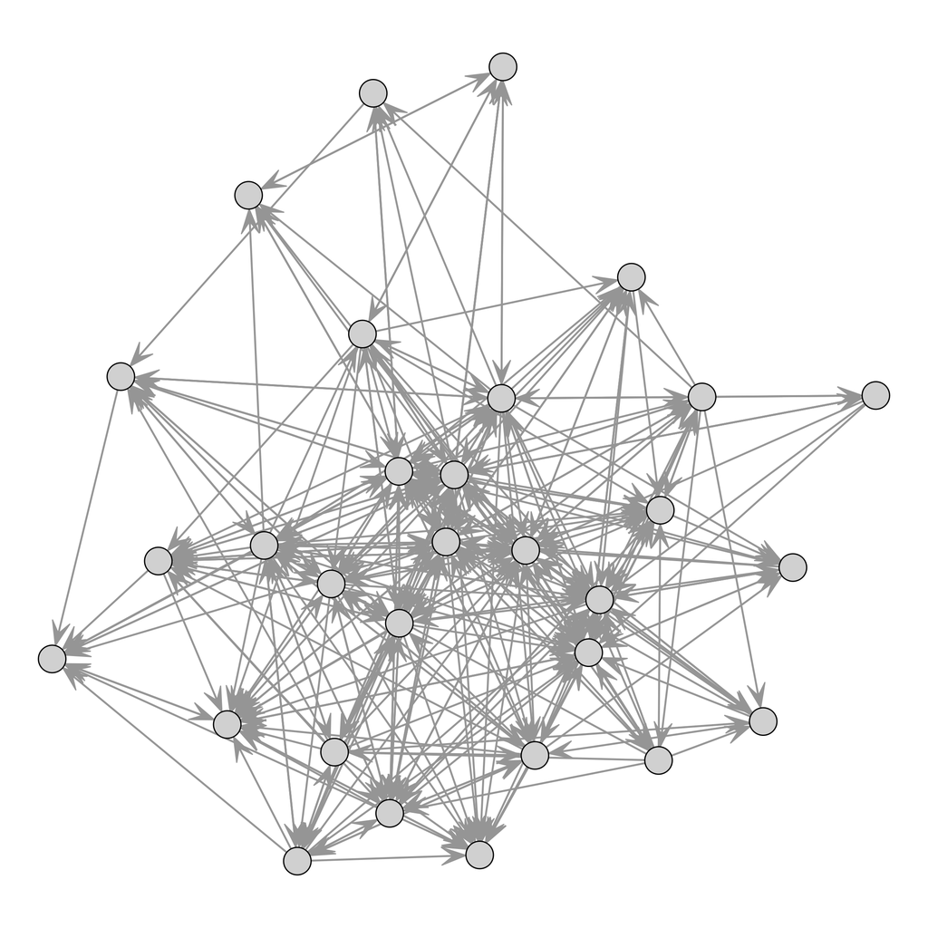

Figure 1: Political Information-Exchange Network

```r
# set seed and save positions for both network figures
set.seed(508)
xy <- network::network.layout.fruchtermanreingold(nw.pol, layout.par = list())

# drop the outer margins so the network fills the panel
op <- par(mar = c(0, 0, 0, 0))

# first look: show the basic structure before highlighting mutual ties
plot(nw.pol, coord = xy, jitter = FALSE,
     displaylabels = FALSE, displayisolates = TRUE,
     vertex.col = "gray85", vertex.cex = 1.6,
     edge.col = "gray65", edge.lwd = 0.8, arrowhead.cex = 1.5)
```

```r
par(op)
```

*Note.* Arrows point from the nominating organization to its named partner.

Figure 1 shows the overall pattern of nominations. I hold these node positions fixed in Figure 2 so that the visual comparison reflects a change in the highlighted ties.

# Part 2. Reciprocity and Transitivity

**Research Question**: How reciprocal and transitive are organizations’ reported information-exchange ties?

## 2.1 Reciprocity

### From Directed Ties to Mutual Dyads

**Reciprocity** concerns a pair of actors: if $i$ nominates $j$, does $j$ also nominate $i$?

A dyad can be **(1) mutual** ($i \leftrightarrow j$), **(2) asymmetric** (only one nomination), or **(3) null** (neither nomination). These distinctions follow the mutual, asymmetric, and null relations described by Holland & Leinhardt (1971).

Reciprocity is also a basic example of endogenous network dependence in Cranmer et al. (2020): the configuration involves two related edge indicators.

For this network, **mutuality** means *agreement about an exchange partnership*. It does not establish equal quantities of information exchanged or prove that one nomination caused the other (Leifeld & Schneider, 2012).

```r
# multiply each tie by its reverse tie
# a cell equals 1 only when both nominations are present
mutual <- pol * t(pol)

# count each unordered pair once
M <- sum(mutual[upper.tri(mutual)])
A <- L - 2 * M
N <- choose(n, 2) - M - A

# the three dyad types must exhaust all unordered pairs
stopifnot(M + A + N == choose(n, 2))

dyads <- data.frame(
  Type = c("Mutual", "Asymmetric", "Null", "Total"),
  Count = c(M, A, N, choose(n, 2))
)

kable(dyads, format = "html", caption = "Dyad Census") %>%
  kable_styling(full_width = TRUE,
                bootstrap_options = c("hover", "condensed", "responsive")) %>%
  row_spec(nrow(dyads), bold = TRUE)
```

Table 3: Dyad Census

| Type | Count |
| --- | --- |
| Mutual | 105 |
| Asymmetric | 132 |
| Null | 198 |
| Total | 435 |

Table 3 reports 105 mutual dyads among the 435 pairs of organizations. Each mutual dyad contains two directed ties and each asymmetric dyad contains one, which recovers the 342 nominations in Table 2: 210 + 132 = 342. So 210 of the 342 observed nominations are reciprocated. Counting dyads and counting edges therefore give different numerators.

### Raw Reciprocity and Density Adjustment

The traditional measure discussed by Garlaschelli & Loffredo (2004), **raw edge reciprocity**, is the proportion of observed directed ties with a reverse tie:

$$r = \frac{\sum_{i \ne j} A_{ij}A_{ji}}{L} = \frac{2M}{L}
\tag{1}$$

Here, $A_{ij}$ is the binary adjacency entry, $M$ is the number of mutual dyads, and $L$ is the number of directed edges.

For example, one mutual dyad and one asymmetric dyad contain three edges; two are reciprocated, giving $r=2/3$.

*Raw reciprocity does not account for density*. A denser network provides more opportunities for a reverse tie even without a tendency toward mutuality. Garlaschelli & Loffredo (2004) introduce a density-adjusted measure, equivalent to the correlation between off-diagonal adjacency entries and their reverse entries:

$$\rho = \frac{r-d}{1-d}, \qquad d=\frac{L}{n(n-1)}
\tag{2}$$

The reference is a network of independent directed ties with a common connection probability $d$. Positive $\rho$ indicates reciprocity above this density-based reference; zero indicates equality with the reference; negative values indicate less reciprocity than the reference. This adjustment is not itself a statistical significance test.

```r
# check denominators before calculating either measure
stopifnot(L > 0, density < 1)

# raw edge reciprocity
reciprocity_raw <- 2 * M / L

# density-adjusted reciprocity: Garlaschelli and Loffredo (2004)
reciprocity_adjusted <- (reciprocity_raw - density) / (1 - density)

# default dyadic reciprocity in sna: proportion of mutual and null dyads
reciprocity_dyadic <- (M + N) / (M + A + N)
```

Raw reciprocity is $2M/L = 210/342 = 0.614$: approximately 61.4% of nominations have a reverse nomination.

Adjusted reciprocity is $(r-d)/(1-d) = (0.614 - 0.393)/(1 - 0.393) = 0.364$, indicating more mutuality than the density-based reference. It is a correlation measure, not a percentage of reciprocated ties.

By default, `sna::grecip(nw.pol)` uses `measure = "dyadic"` and returns the proportion of dyads that are symmetric, including both mutual and null dyads: $(M+N)/(M+A+N) = 0.697$. This differs from both raw edge reciprocity and the density-adjusted $\rho$ above.

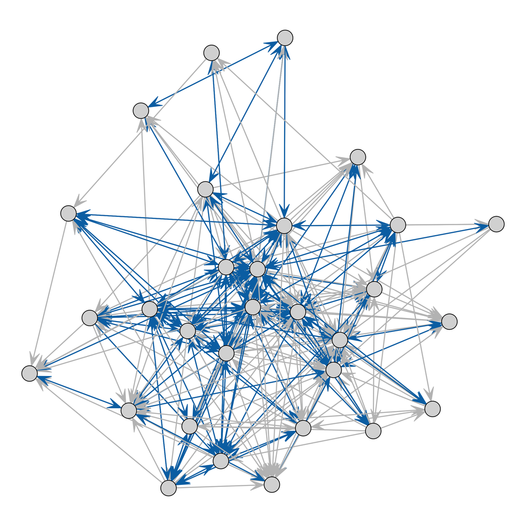

Figure 2: Reciprocal Information-Exchange Ties

```r
# use color-blind-friendly blue #0072B2 for mutual nominations and gray for asymmetric nominations
# a color matrix to match colors by sender and receiver
edge_colors <- ifelse(mutual == 1, "#0072B2", "gray75")

# same margins and sizing as the first network figure
op <- par(mar = c(0, 0, 0, 0))

plot(nw.pol, coord = xy, jitter = FALSE,
     displaylabels = FALSE, displayisolates = TRUE,
     vertex.col = "gray85", vertex.cex = 1.6,
     edge.col = edge_colors, edge.lwd = 0.8, arrowhead.cex = 1.5)
```

```r
par(op)
```

*Note.* Blue arrows indicate reciprocated nominations; gray arrows indicate asymmetric nominations. Node positions are unchanged from Figure 1.

The highlighted ties in Figure 2 show where nominations are mutual. The plot locates the pattern; the reciprocity statistics summarize its prevalence.

## 2.2 Transitivity

### From Two-Paths to Transitive Closure

**Transitivity** concerns three distinct actors. If $i$ nominates $j$ and $j$ nominates $k$, a **directed two-path** exists. It is transitively closed when $i$ also nominates $k$:

$$i \rightarrow j,\quad j \rightarrow k
\quad\text{and}\quad i \rightarrow k$$

Holland & Leinhardt (1971) define a transitive relation through this implication. Their exact structural model has a strong consequence: mutual relations form cliques, with asymmetric relations between cliques forming a partial order; pairs of cliques with no asymmetric relations are unranked.

An empirical network can contain many transitive configurations without satisfying this implication everywhere.

**Direction** matters. Adding $k \rightarrow i$ instead creates a cycle, not the transitive closure of $i \rightarrow j \rightarrow k$. Cranmer et al. (2020) distinguish these configurations in their Figure 3.5. Figure 3 illustrates the distinction here.

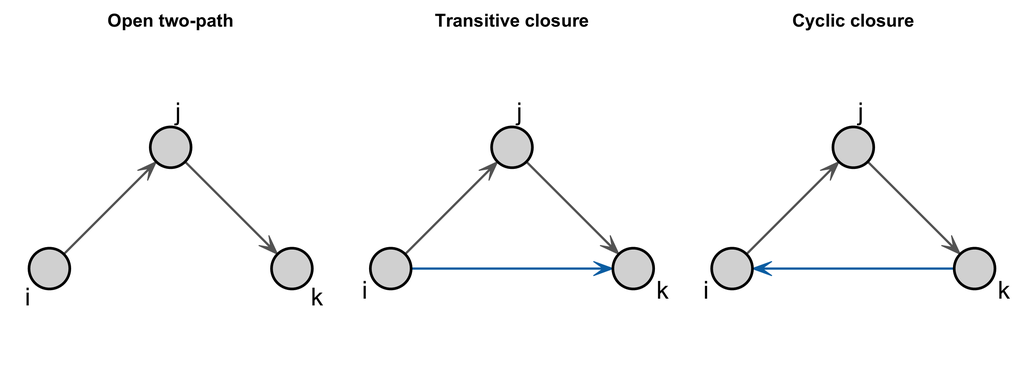

Figure 3: Transitive and Cyclic Closure

```r
# create three small examples with the same node positions
open <- matrix(0, 3, 3)
open[1, 2] <- 1
open[2, 3] <- 1

transitive <- open
transitive[1, 3] <- 1

cyclic <- open
cyclic[3, 1] <- 1

triads <- list("Open two-path" = open,
               "Transitive closure" = transitive,
               "Cyclic closure" = cyclic)
xy_triad <- rbind(c(-1, 0), c(0, 1), c(1, 0))

# compare configurations, holding positions fixed
op <- par(mfrow = c(1, 3), mar = c(1, 1, 3, 1))
for (name in names(triads)) {
  triad <- network::network(triads[[name]], directed = TRUE,
                            matrix.type = "adjacency")
  added <- triads[[name]] == 1 & open == 0
  plot(triad, coord = xy_triad, jitter = FALSE,
       displaylabels = TRUE, label = c("i", "j", "k"),
       vertex.col = "gray85", vertex.cex = 7,
       label.cex = 2.2, vertex.lwd = 2.5, edge.lwd = 4,
       edge.col = ifelse(added, "#0072B2", "gray40"),
       arrowhead.cex = 3.5, main = name, cex.main = 1.6)
}
```

```r
par(op)
```

*Note.* Gray arrows show the original two-path. Blue arrows mark the added tie: $i \rightarrow k$ closes it transitively; $k \rightarrow i$ creates a cycle.

We should check: in the cyclic example, which arrow would close the two-path from $i$ through $j$ to $k$ transitively? The required arrow is $i \rightarrow k$; the existing $k \rightarrow i$ points the other way.

### Measuring Directed Transitivity

For this tutorial, I measure directed transitivity as the fraction of directed two-paths that are transitively closed:

$$T = \frac{\sum_{i,j,k\text{ distinct}} A_{ij}A_{jk}A_{ik}}
{\sum_{i,j,k\text{ distinct}} A_{ij}A_{jk}}
\tag{3}$$

The numerator counts closed two-paths; the denominator counts all two-paths through three distinct actors. A set of three organizations can contribute multiple ordered configurations when additional ties are present. Thus, the numerator is not a count of unique three-organization groups. This normalized descriptive measure builds on the transitive configuration discussed by Holland & Leinhardt (1971) and Cranmer et al. (2020); it corresponds to the weak transitivity measure in `sna::gtrans()`. It is not the geometrically weighted shared-partner statistic used in the ERGMs (Exponential Random Graph Models) of Leifeld & Schneider (2012). Unlike adjusted reciprocity above, this closure proportion does not adjust for density.

```r
# matrix multiplication counts two-paths from each row to each column
# diagonal entries return to the starting actor, so exclude them
two_paths <- pol %*% pol
diag(two_paths) <- 0

# count all eligible two-paths and those with a direct closing tie
n_two_paths <- sum(two_paths)
n_closed <- sum(two_paths * pol)

# transitivity is undefined if there are no eligible two-paths
transitivity_directed <- if (n_two_paths > 0) n_closed / n_two_paths else NA_real_

# report the denominator as well as the coefficient
transitivity_table <- data.frame(
  Two_paths = n_two_paths,
  Closed_two_paths = n_closed,
  Transitivity = round(transitivity_directed, 3)
)

kable(transitivity_table, format = "html", caption = "Directed Transitivity",
      col.names = c("Two-paths", "Closed two-paths", "Transitivity")) %>%
  kable_styling(full_width = TRUE,
                bootstrap_options = c("hover", "condensed", "responsive"))
```

Table 4: Directed Transitivity

| Two-paths | Closed two-paths | Transitivity |
| --- | --- | --- |
| 4254 | 2661 | 0.626 |

Table 4 shows that, of 4,254 directed two-paths, 2,661 have the direct closing nomination. Transitivity is 2,661 / 4,254 = 0.626: approximately 62.6% of eligible two-paths are closed. This describes an observed pattern of partner nominations; it does not demonstrate that a relationship formed through an intermediary over time.

## 2.3 Verification with `sna` Built-In Functions

The following code cross-checks the by-hand calculations against the corresponding functions in the `sna` package.

```r
# sna workflow:
# calculate the same statistics using sna built-in functions
dyads_sna <- sna::dyad.census(nw.pol)
reciprocity_dyadic_sna <- unname(sna::grecip(nw.pol))
reciprocity_raw_sna <- unname(sna::grecip(nw.pol, measure = "edgewise"))
reciprocity_adjusted_sna <- unname(sna::grecip(nw.pol, measure = "correlation"))
transitivity_sna <- unname(sna::gtrans(nw.pol, measure = "weak"))

# verify that the by-hand calculations match the sna results
# `stopifnot()` checks cause knitting to stop if any result does not match
stopifnot(
  identical(unname(dyads_sna[1, c("Mut", "Asym", "Null")]), c(M, A, N)),
  isTRUE(all.equal(reciprocity_dyadic, reciprocity_dyadic_sna)),
  isTRUE(all.equal(reciprocity_raw, reciprocity_raw_sna)),
  isTRUE(all.equal(reciprocity_adjusted, reciprocity_adjusted_sna)),
  isTRUE(all.equal(transitivity_directed, transitivity_sna))
)

# compare the by-hand and sna results
verification <- data.frame(
  Measure = c("Mutual dyads", "Asymmetric dyads", "Null dyads",
              "Default dyadic reciprocity", "Raw edge reciprocity",
              "Density-adjusted reciprocity", "Directed transitivity"),
  By_hand = c(as.character(M), as.character(A), as.character(N),
              sprintf("%.3f", reciprocity_dyadic),
              sprintf("%.3f", reciprocity_raw),
              sprintf("%.3f", reciprocity_adjusted),
              sprintf("%.3f", transitivity_directed)),
  sna = c(as.character(dyads_sna[1, "Mut"]),
          as.character(dyads_sna[1, "Asym"]),
          as.character(dyads_sna[1, "Null"]),
          sprintf("%.3f", reciprocity_dyadic_sna),
          sprintf("%.3f", reciprocity_raw_sna),
          sprintf("%.3f", reciprocity_adjusted_sna),
          sprintf("%.3f", transitivity_sna))
)

kable(verification, format = "html", caption = "Verification with sna Built-In Functions",
      col.names = c("Measure", "By-hand calculation", "sna result"),
      align = c("l", "r", "r")) %>%
  kable_styling(full_width = TRUE,
                bootstrap_options = c("hover", "condensed", "responsive"))
```

Table 5: Verification with sna Built-In Functions

| Measure | By-hand calculation | sna result |
| --- | --- | --- |
| Mutual dyads | 105 | 105 |
| Asymmetric dyads | 132 | 132 |
| Null dyads | 198 | 198 |
| Default dyadic reciprocity | 0.697 | 0.697 |
| Raw edge reciprocity | 0.614 | 0.614 |
| Density-adjusted reciprocity | 0.364 | 0.364 |
| Directed transitivity | 0.626 | 0.626 |

Table 5 confirms that the dyad census, raw edge reciprocity, and directed transitivity match the `sna` built-in functions. It also confirms the separate default dyadic reciprocity measure.

## 2.4 Comparing the Measures

Table 6 brings the measures together.

**Reciprocity** asks whether a nomination is returned.

**Transitivity** asks whether a two-path is closed by a direct nomination.

Their denominators differ, so their numerical values should not be treated as competing measures of the same property.

```r
# combine descriptive measures for interpretation
comparison <- data.frame(
  Measure = c("Density", "Raw reciprocity", "Adjusted reciprocity",
              "Directed transitivity"),
  Value = round(c(density, reciprocity_raw, reciprocity_adjusted,
                  transitivity_directed), 3),
  Interpretation = c(
    "Share of possible directed ties observed",
    "Share of observed ties with a reverse tie",
    "Reciprocity relative to the density-based reference",
    "Share of directed two-paths transitively closed"
  )
)

kable(comparison, format = "html", caption = "Comparing Network Measures",
      align = c("l", "r", "l")) %>%
  kable_styling(full_width = TRUE,
                bootstrap_options = c("hover", "condensed", "responsive"))
```

Table 6: Comparing Network Measures

| Measure | Value | Interpretation |
| --- | --- | --- |
| Density | 0.393 | Share of possible directed ties observed |
| Raw reciprocity | 0.614 | Share of observed ties with a reverse tie |
| Adjusted reciprocity | 0.364 | Reciprocity relative to the density-based reference |
| Directed transitivity | 0.626 | Share of directed two-paths transitively closed |

Tam Cho & Fowler (2010) provide an application of clustering in an undirected shared-cosponsorship network. Their network-level clustering measure averages local clustering coefficients, and their small-world analysis also considers path length relative to a reference network. This differs from the directed two-path measure used here.

Ignoring direction would erase the distinction between the transitive and cyclic examples; clustering alone would also be insufficient to establish small-world structure.

## Conclusion

This tutorial describes two features of the political information-exchange network in Leifeld & Schneider (2012).

First, 61.4% of nominations are reciprocated, with positive density-adjusted reciprocity.

Second, 62.6% of directed two-paths are transitively closed. The first result concerns mutual acknowledgment between two organizations; the second concerns closure among three organizations.

These descriptive results do not reproduce the authors’ ERGM estimates or test their explanations of tie formation.

Leifeld & Schneider (2012) model reciprocity with a mutual-dyad term and shared-partner structure with GWESP (Geometrically Weighted Edgewise Shared Partners) and GWDSP (Geometrically Weighted Dyadwise Shared Partners), alongside other institutional and relational factors.

Their model coefficients are distinct from the descriptive proportions calculated here. The present analysis establishes what the configurations mean and how to measure them before moving to statistical inference (Cranmer et al., 2020).

The key takeaways are:

- (1) define the relation before interpreting its structure
- (2) specify the denominator of each measure
- (3) preserve tie direction when distinguishing transitivity from cyclic closure

## References

Cranmer, S. J., Desmarais, B. A., & Morgan, J. W. (2020). *[Inferential network analysis](https://doi.org/10.1017/9781316662915)* (1st ed.). Cambridge University Press.

Garlaschelli, D., & Loffredo, M. I. (2004). [Patterns of link reciprocity in directed networks](https://doi.org/10.1103/PhysRevLett.93.268701). *Physical Review Letters*, *93*(26), 268701.

Holland, P. W., & Leinhardt, S. (1971). Transitivity in structural models of small groups. *Small Group Research*, *2*(2), 107–124.

Leifeld, P., & Schneider, V. (2012). [Information exchange in policy networks](https://doi.org/10.1111/j.1540-5907.2011.00580.x). *American Journal of Political Science*, *56*(3), 731–744.

Tam Cho, W. K., & Fowler, J. H. (2010). [Legislative success in a small world: Social network analysis and the dynamics of congressional legislation](https://doi.org/10.1017/S002238160999051X). *The Journal of Politics*, *72*(1), 124–135.